# Eksploracja / cechy jakościowe

W trakcie tych zajęć przedstawimy podstawowe operacje na danych jakościowych. Ale zanim dojdziemy do tych operacji najpierw wczytajmy dane.

# Wczytanie danych

```r
auta2012 = read.table("http://biecek.pl/MOOC/dane/auta2012.csv",
                       sep=";", dec=",", header=TRUE)
head(auta2012, 2)
```

```
##    Cena Waluta Cena.w.PLN Brutto.netto  KM  kW      Marka     Model Wersja
## 1 49900    PLN      49900       brutto 140 103        Kia    Carens
## 2 88000    PLN      88000       brutto 156 115 Mitsubishi Outlander
##   Liczba.drzwi Pojemnosc.skokowa Przebieg.w.km          Rodzaj.paliwa
## 1          4/5              1991         41000 olej napedowy (diesel)
## 2          4/5              2179         46500 olej napedowy (diesel)
##   Rok.produkcji Kolor Kraj.aktualnej.rejestracji Kraj.pochodzenia
## 1          2008                           Polska
## 2          2008                           Polska
##   Pojazd.uszkodzony Skrzynia.biegow Status.pojazdu.sprowadzonego
## 1                          manualna
## 2                          manualna
##                                                                                                                                                                                Wyposazenie.dodatkowe
## 1                         ABS, el. lusterka, klimatyzacja, alufelgi, centralny zamek, autoalarm, poduszka powietrzna, radio / CD, wspomaganie kierownicy, immobiliser, komputer, przyciemniane szyby
## 2 ABS, 4x4, el. lusterka, klimatyzacja, skorzana tapicerka, alufelgi, centralny zamek, poduszka powietrzna, radio / CD, wspomaganie kierownicy, immobiliser, komputer, tempomat, przyciemniane szyby
##   Informacje.dodatkowe
## 1  pierwszy wlasciciel
## 2  pierwszy wlasciciel
```

Każdy wiersz tego zbioru danych opisuje jedną ofertę sprzedaży auta. Każda kolumna opisuje jedną cechę / właściwość tej oferty.

# Cechy jakościowe

Przyjrzyjmy się teraz takim cechom jak `Waluta` lub `Marka`. Cechy te są opisane przez wartości z określonej listy możliwości. Dla cechy `Waluta` lista możliwości to CHF, CZK, EEK, EUR, GBP, HUF, PLN, USD. Takie cechy określa się cechami jakościowymi w odróżnieniu od cech ilościowych.

## Statystyki opisowe

Dla cech jakościowych możemy wykonać kilka operacji. Jedną z nich jest wyświetlenie listy możliwych wartości. Taką listę nazywa się często słownikiem (spisem możliwych wartości).

Listę możliwych wartości dla zmiennej jakościowej można wyznaczyć funkcją `levels()`.

```r
levels(auta2012$Waluta)
```

```
## [1] "CHF" "CZK" "EEK" "EUR" "GBP" "HUF" "PLN" "USD"
```

Zmienne jakościowe często opisuje się tablicą liczebności, a więc informacją ile razy wystąpiła każda z wartości ze słownika. Tablicę liczebności można wyznaczyć funkcją `table()` lub `summary()`.

```r
table(auta2012$Waluta)
```

```
##
##   CHF   CZK   EEK   EUR   GBP   HUF   PLN   USD
##     1 12053     1  2810     4   242 94008   444
```

```r
summary(auta2012$Waluta)
```

```
##   CHF   CZK   EEK   EUR   GBP   HUF   PLN   USD
##     1 12053     1  2810     4   242 94008   444
```

### Zadania:

- Ile zmiennych w zbiorze danych `auta2012` to zmienne jakościowe?
- Zmienna `Liczba.drzwi` przyjmuje wartości `2/3` i `4/5`. Zachowuje się ona jako zmienna jakościowa. Jednak można uznać, że liczba drzwi to cecha ilościowa, ponieważ opisuje *ilość* drzwi w samochodzie. Jak wyjaśnić tę dualność?

### Odpowiedzi:

- Waluta, Brutto.netto, Marka, Model, Wersja, Liczba.drzwi, Rodzaj.paliwa, Kolor, Kraj.aktualnej.rejestracji, Kraj.pochodzenia, Pojazd.uszkodzony, Skrzynia.biegow, Status.pojazdu.sprowadzonego, Wyposazenie.dodatkowe, Informacje.dodatkowe
- Pewne zmienne, w zależności od kontekstu, mogą być traktowane i analizowane jak zmienne ilościowe lub zmienne jakościowe. Do nas należy wybór, która z tych opcji jest właściwsza.

## Procenty

W pewnych sytuacjach, zamiast posługiwać się tablicą liczebności, wygodniej jest posługiwać się tabelą z procentami. Ale jak te procenty policzyć? Pokażemy to na przykładzie kilku funkcji.

Funkcja `prop.table()` dzieli wartości tabeli liczebności przez sumę liczebności, a więc zamienia liczebności na frakcje. Przypiszmy wynik funkcji `table()` do jakiejś zmiennej, np. o nazwie `tabela` (nazwa może być dowolna, musimy jej jednak konsekwentnie używać w dalszych przykładach). Następnie tak otrzymaną tabelę liczebności zamieniamy na frakcje.

W poniższym przykładzie, instrukcję przypisania wyniku obejmujemy napisami, po to by jej wynik był wyświetlony. Bez nawiasów wynik funkcji `table()` nie zostałby wyświetlony.

```r
(tabela = table(auta2012$Waluta))
```

```
##
##   CHF   CZK   EEK   EUR   GBP   HUF   PLN   USD
##     1 12053     1  2810     4   242 94008   444
```

```r
prop.table(tabela)
```

```
##
##       CHF       CZK       EEK       EUR       GBP       HUF       PLN
## 9.127e-06 1.100e-01 9.127e-06 2.565e-02 3.651e-05 2.209e-03 8.580e-01
##       USD
## 4.052e-03
```

Zazwyczaj chcemy mieć wyznaczone procenty a nie frakcje. I to nie byle jakie procenty, ale procenty które są ładnie sformatowane, np. wyświetlone z dokładnością do jednego miejsca dziesiętnego po przecinku. Aby zamienić frakcje na procenty, wystarczy je przemnożyć przez 100, a aby wynik przedstawić z dokładnością do jednego miejsca po przecinku wykorzystamy funkcję `round()`.

```r
(tabela = table(auta2012$Waluta))
```

```
##
##   CHF   CZK   EEK   EUR   GBP   HUF   PLN   USD
##     1 12053     1  2810     4   242 94008   444
```

```r
(frakcje = prop.table(tabela))
```

```
##
##       CHF       CZK       EEK       EUR       GBP       HUF       PLN
## 9.127e-06 1.100e-01 9.127e-06 2.565e-02 3.651e-05 2.209e-03 8.580e-01
##       USD
## 4.052e-03
```

```r
procenty = 100*frakcje
round(procenty, digits = 1)
```

```
##
##  CHF  CZK  EEK  EUR  GBP  HUF  PLN  USD
##  0.0 11.0  0.0  2.6  0.0  0.2 85.8  0.4
```

Ostatnim usprawnieniem tego procesu, które warto rozważyć to uporządkowanie wartości rosnąco lub malejąco. Mając wiele możliwości, w gąszczu liczb czasem trudno nawet dostrzec, która jest największa. Posortowawszy te liczby łatwiej dostrzec najmniejsze i największe. Do sortowania można wykorzystać funkcję `sort()`. Dodając argument `decreasing = TRUE` powodujemy, że wartości będą uporządkowane malejąco.

```r
zaokragloneProcenty = round(procenty,1)
sort(zaokragloneProcenty)
```

```
##
##  CHF  EEK  GBP  HUF  USD  EUR  CZK  PLN
##  0.0  0.0  0.0  0.2  0.4  2.6 11.0 85.8
```

```r
sort(zaokragloneProcenty, decreasing = TRUE)
```

```
##
##  PLN  CZK  EUR  USD  HUF  CHF  EEK  GBP
## 85.8 11.0  2.6  0.4  0.2  0.0  0.0  0.0
```

### Zadania:

- Cecha `Marka` opisuje markę samochodu. Sprawdź, która marka jest najpopularniejsza.
- Cecha `Rodzaj.paliwa` opisuje rodzaj paliwa wykorzystywanego przez auto. Czy jest to benzyna, olej, gaz? Sprawdź jaki procent samochodów jest napędzana na benzynę.

### Odpowiedzi:

- Volkswagen
- 38.6882 %

## Graficzne statystyki opisowe

Tabele liczebności są proste w interpretacji. Podobnie jednak jak w innych przypadkach, graficzne przedstawienie tych liczb pozwala na łatwiejsze dostrzeżenie zależności pomiędzy danymi. Koniec końców w tabeli liczb łatwo pomylić się nawet gdy chodzi o liczbę cyfr w licznie. Na wykresie takie różnice natychmiast rzucają się w oczy.

```r
(tabela = table(auta2012$Waluta))
```

```
##
##   CHF   CZK   EEK   EUR   GBP   HUF   PLN   USD
##     1 12053     1  2810     4   242 94008   444
```

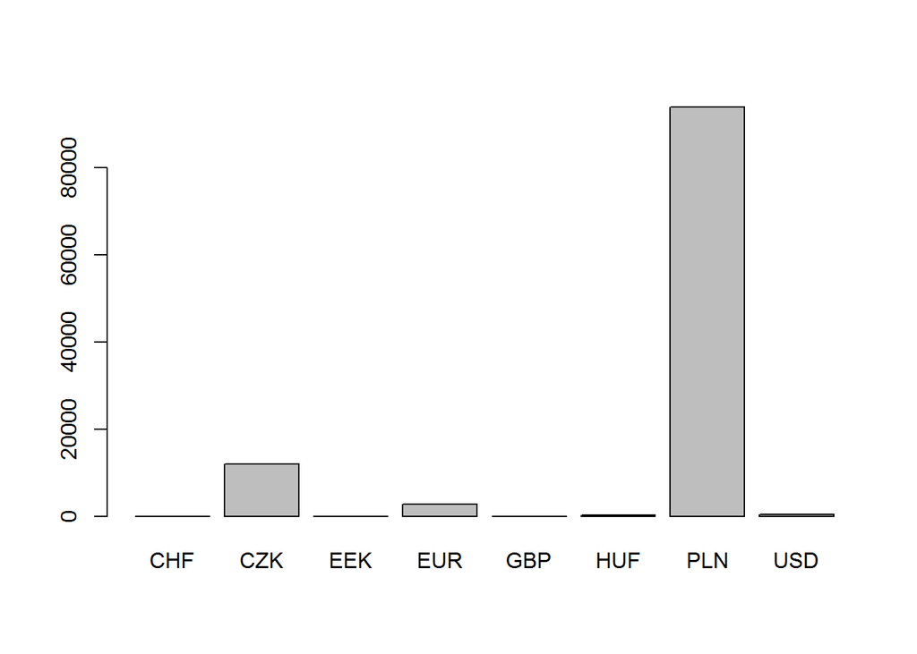

```r
barplot(tabela)
```

Jeżeli chcemy, by słupki były przedstawiane poziomo, można dodać argument `horiz = TRUE`.

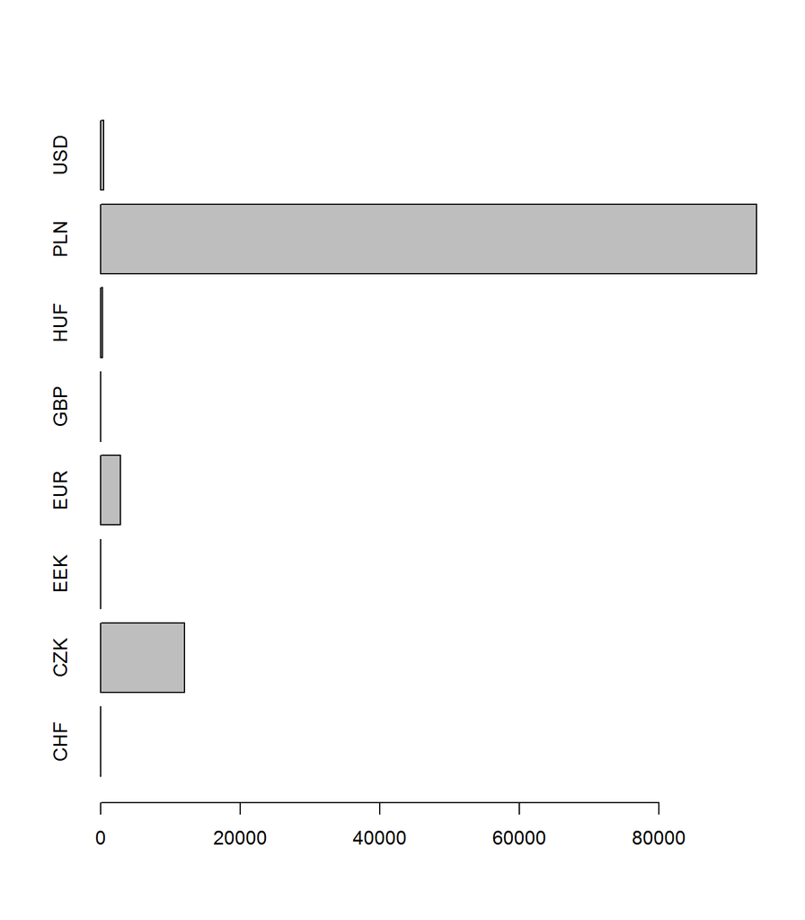

```r
barplot(tabela, horiz = TRUE)
```

Domyślnie wartości są uporządkowane alfabetycznie. Nie zawsze jednak taka kolejność ma sens. W tym przypadku rozsądniej jest posortować dane malejąco, co można wykonać z użyciem funkcji `sort()`. Argument `las=1` powoduje, że oś OY ma etykiety ustawione poziomo.

```r
(posortowanaTabela = sort(tabela))
```

```
##
##   CHF   EEK   GBP   HUF   USD   EUR   CZK   PLN
##     1     1     4   242   444  2810 12053 94008
```

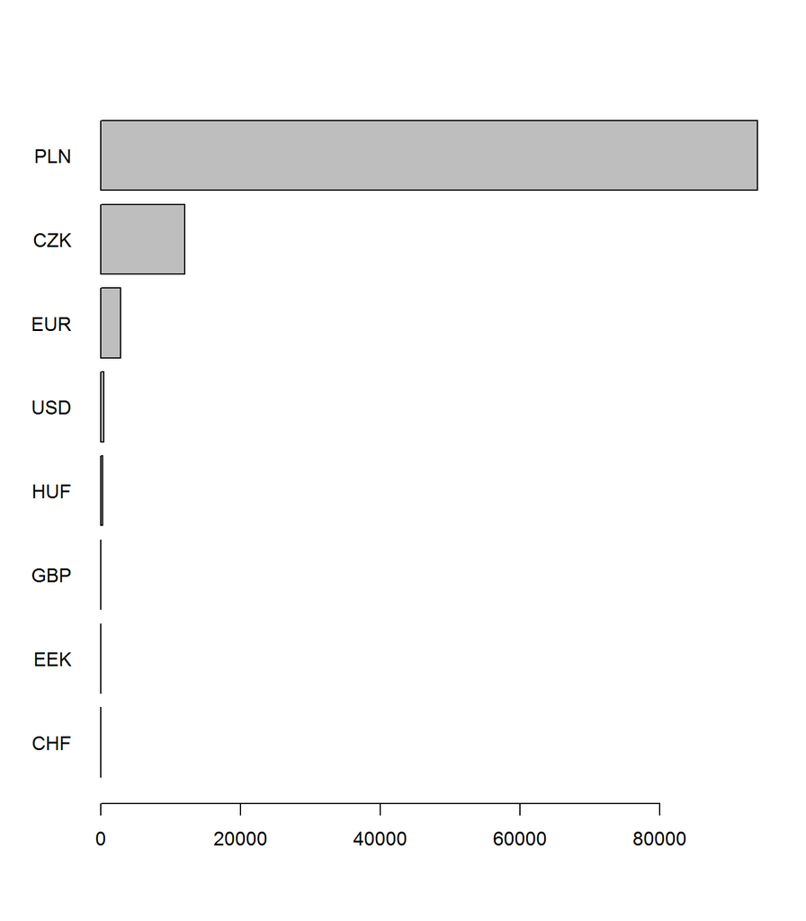

```r
barplot(posortowanaTabela, horiz = TRUE, las=1)
```

### Zadania:

- Przedstaw graficznie tabelę liczebności dla zmiennej `Kraj.pochodzenia`. Wypróbuj wykres pionowy i poziomy. Aby obrócić kierunek etykiet na osiach dodaj do funkcji `barplot()` argument `las=1`.

### Odpowiedzi:

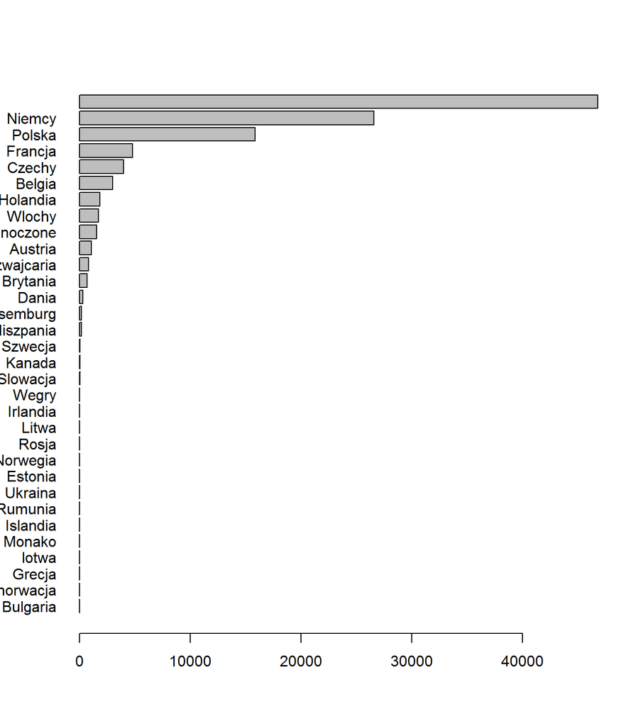

```r
posortowanaTabela = sort(table(auta2012$Kraj.pochodzenia))
barplot(posortowanaTabela, horiz = TRUE, las=1)
```

Podobnie graficznie można przedstawiać cechy logiczne i napisowe.